# TRATAMIENTO DE DATOS CON R

Joaquín Planelles Romero e Isabel Padilla Sánchez

octubre de 2021

# tidyverse

[figure not shown]

Se denomina tidyverse a un conjunto de librerías de R concebidas para el trabajo en Ciencia de Datos. En estas librerías están programadas una serie de funciones que facilitan el trabajo en las distintas fases del ciclo del dato: recogida de la información, tratamiento y difusión de resultados. Con ellas se puede hacer web-scrapping, tratamiento de textos, gráficos interactivos, informes automatizados… Se trata, además, de unas librerías de uso muy extendido, lo que facilita encontrar documentación para resolver cualquier problema concreto.

Las librerías que componen tidyverse comparten un diseño y una gramática comunes, lo que facilita la inter-operabilidad entre las distintas librerías/fases del ciclo del dato. En este sentido, podemos decir que tidyverse es una subcultura dentro del trabajo con R. El autor del concepto y de muchas de estas librerías es el científico jefe de RStudio, Hadley Wickham.

En este curso, dedicado al “tratamiento de conjuntos de datos y programación estadística con R” vamos a familiarizarnos con varias de estas librerías, concebidas para el trabajo en las fases centrales (tratamiento) del ciclo del dato.

Para profundizar en tidyverse más allá de los contenidos de este curso, os remitimos a su propia página web, en la que encontraréis descripciones de cada librería e información sobre sus funciones y argumentos correspondientes: https://www.tidyverse.org. Y también al libro escrito por los creadores de tidyverse: [R for data science](https://r4ds.had.co.nz/) de Hadley Wickham y Garrett Grolemund, para el que también existe desde hace poco una versión completa en español: [R para ciencia de datos](https://es.r4ds.hadley.nz/)

# Gramática tidyverse

Los paquetes de tidyverse son interoperables y tienen una misma ‘filosofía de trabajo’. He aquí dos de esos principios compartidos por los paquetes de tidyverse: uso de tuberías y de datos ordenados

### 1. Uso de tuberías

Las tuberías son un operador que sirve para realizar varias operaciones de forma secuencial sin recurrir a paréntesis anidados o a realizar una operación en cada línea de código (con lo que eso supone en términos de extensión del script y de crear/sobrescribir multitud de objetos). Se representan mediante el símbolo `%>%`.

Para ver como funciona esto, supongamos que tenemos un vector x, compuesto por los números pares entre el 2 y el 10. Para ellos queremos realizar algunas transformaciones: primero, obtener el logaritmo de cada elemento. Una vez hecha esa transformación queremos obtener la raíz cuadrada. Finalmente, queremos calcular el promedio de los distintos elementos que constituyen el vector transformado y mostrarlo redondeado al primer decimal. Para realizar esto lo convencional consistiría en anidar las operaciones, del siguiente modo:

```r
x <- c(2, 4, 6, 8, 10)
y <- round(mean(sqrt(log(x))), 1)
```

En cambio, si se utilizan tuberías, es mucho más fácil de interpretar a primera vista ya que se lee de izquierda a derecha y no de adentro hacia afuera:

```r
y <- x %>% log() %>% sqrt() %>% mean() %>% round(1)
```

### 2. Uso de datos ordenados o ‘datos tidy’

Es importante estructurar los datos bien para que la respuesta sea eficiente (rápida). Tanto es así que ‘tidy’ significa ‘ordenado’. Es decir, `tidyverse` significa literalmente, ‘el universo ordenado’. R es un lenguaje muy eficiente al trabajar con vectores. Para aprovechar esa potencialidad, `tidyverse` necesita trabajar con datos rectangulares, organizados por filas y columnas (filas contiguas y del mismo tamaño, columnas contiguas y del mismo tamaño).

Los objetos rectangulares de uso más común en R son data.frames y tibbles. Los tibbles son algo así como unos data.frames evolucionados y son la estructura de datos preferida por los paquetes de ‘tidyverse’.

Aunque esto pueda parecer una obviedad, nuestras fuentes de información no siempre tendrán esa forma rectangular. Y de hecho, ni siquiera será lo más frecuente. Si importamos la información de hojas de cálculo, documentos pdf o haciendo web scrapping en la web, la información estará generalmente almacenada en un formato no-estructurado (muy probablemente se habrán editado con filas/columnas en blanco, o ubicando en la misma hoja varias tablas, una al lado de otra, etcétera). Por ello, habrá que importar esos datos con cuidado, trayendo los distintos bloques rectangulares de información por separado, para que no de lugar a problemas del estilo del que se observa en el ejemplo siguiente:

Información con estructura no rectangular en excel

Información rectangular (21 filas, 6 columnas) que lee erróneamente R

[figure not shown]

[figure not shown]

`tidyverse` utiliza datos rectangulares. Las funciones de las librerías de tidyverse requieren para poder funcionar de esa estructura de datos rectangular (filas/columnas). Pero ¡ojo!, pues un mismo conjunto de datos se puede mostrar con distintos rectángulos, en función de qué pongamos en filas y columnas. Y no todos los rectángulos almacenan la información igual de bien. Para mostrarlo, hemos preparado tres ejemplos que contienen datos para tres municipios andaluces: Almería, El Ejido y Sevilla. Los datos que muestran las tablas relativos a estos municipios son su extensión en km cuadrados, su salario anual y su número de asalariados. No obstante, como la ubicación de las filas y columnas difiere en los distintos ejemplos, la forma del rectángulo/tabla también varía.

`tidyverse` está pensado para trabajar más eficientemente con una estructura de datos como la del ‘Ejemplo 3’, en la que las unidades de análisis ocupan cada una una fila, mientras que los atributos asociados a las mismas ocupan cada uno una columna. A esto es a lo que se llama datos ordenados o ‘datos tidy’.

Ejemplo 1. Datos rectangulares no ordenados

Ejemplo 2. Datos rectangulares no ordenados

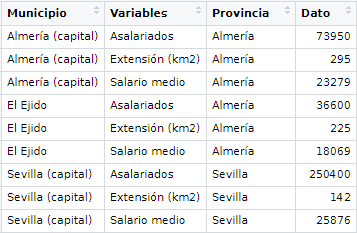

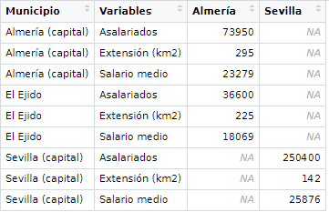

**Ejemplo 3. Datos rectangulares ordenados**

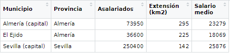

# El núcleo de tidyverse

El núcleo de tidyverse lo componen 8 paquetes o librerías, que son los de uso más frecuente. Estas 8 librerías se pueden instalar y cargar por separado o todas juntas. Para instalarlas todas juntas habrá que utilizar el comando `install.packages('tidyverse')`. Una vez instaladas, para cargarlas en la sesión de trabajo, habrá que utilizar, como si de una única librería se tratara, el comando `library(tidyverse)`.

En la imagen siguiente se presentan los iconos de cada una de estas librerías y su cometido principal. Si queréis profundizar en las funcionalidades de cada una, os recomendamos que os dirijáis directamente a la propia [página de tidyverse](https://www.tidyverse.org/packages/). En este curso veremos con cierto detalle 3 de estas librerías: `dplyr`, `tidyr` y `tibble`.

[figure not shown]

# Otros paquetes de tidyverse

`tidyverse` incluye muchos otros paquetes, de uso más especializado, por lo que no forman parte del núcleo. Por ello, estos paquetes no se cargan con `library('tidyverse')`, sino que habrá que cargar cada uno de ellos por separado cuando queramos acceder a las funciones más específicas que tienen implementadas. He aquí **algunos** de estos paquetes:

[figure not shown]

Estas librerías permiten hacer distintas cosas:

- Unas facilitan tratar con un determinado tipo de datos. En este curso, por ejemplo, vamos a hablar del paquete `lubridate`, especialmente diseñado para tratar con fechas y duraciones.
- Otros paquetes funcionan como traductores. Desde RStudio están construyendo una especie de ‘piedra rosetta’ que permite transformar el código `dplyr` que hayas escrito en código optimizado para otros lenguajes de programación. Es un proceso prácticamente ciego para el usuario: tú escribes tu código `dplyr` en la consola de `RStudio` y por detrás se transforma en sentencias de otro lenguaje que se corren y te devuelven el objeto deseado.

  En este curso haremos referencia a dos de estos paquetes: `dbplyr` permite transformar tu código `dplyr` en un código SQL. Esto te permite, por ejemplo, conectarte desde R a una base de datos externa y pedirle que realice determinadas acciones mediante sentencias SQL. Como veremos, esta puede ser una estrategia muy potente de cara a evadir las limitaciones de R con la memoria volátil (RAM). En este curso también haremos referencia a `dtplyr` que permite transformar tu código dplyr en código data.table.
- Finalmente, hay un conjunto amplio de paquetes de `tidyverse` especialmente diseñados para constuir modelos y para programar. Estos paquetes quedan fuera del ámbito de este curso.

# Preguntas de auto-evaluación

El objetivo de las siguientes preguntas es que podáis auto-evaluar si habéis adquirido los conocimientos. Encontraréis las respuestas en la pestaña de soluciones.

- **Pregunta 1**. ¿Cuál de los siguientes paquetes/librerías de R no pertenece a ‘tidyverse’?
  1. data.table
  2. dplyr
  3. tidyr
  4. lubridate
- **Pregunta 2**. ¿Qué operador representa las tuberías?
  1. %%
  2. :)
  3. %>%
  4. %=%
- **Pregunta 3**. ¿Qué paquete te permite transformar tu código dplyr en código SQL?
  1. SQLyr
  2. SQLtoR
  3. tidyverse
  4. dbplyr
- **Pregunta 4**. Señala cuál de estas afirmaciones **no es cierta**
  1. Los datos ordenados son siempre datos rectangulares
  2. Los datos ordenados tienen todas las filas de la misma longitud/dimensión
  3. Los datos rectangulares son siempre datos ordenados
  4. Los datos rectangulares tienen todas las columnas de la misma longitud/dimensión

# Soluciones

A continuación se muestran, marcadas y en rojo, las soluciones a las preguntas de auto-evaluación

- **Pregunta 1**. ¿Cuál de los siguientes paquetes/librerías de R no pertenece a ‘tidyverse’?
  1. **data.table**
  2. dplyr
  3. tidyr
  4. lubridate
- **Pregunta 2**. ¿Qué operador representa las tuberías?
  1. %%
  2. :)
  3. **%>%**
  4. %=%
- **Pregunta 3**. ¿Qué paquete te permite transformar tu código dplyr en código SQL?
  1. SQLyr
  2. SQLtoR
  3. tidyverse
  4. **dbplyr**
- **Pregunta 4**. Señala cuál de estas afirmaciones **no es cierta**
  1. Los datos ordenados son siempre datos rectangulares
  2. Los datos ordenados tienen todas las filas de la misma longitud/dimensión
  3. **Los datos rectangulares son siempre datos ordenados**
  4. Los datos rectangulares tienen todas las columnas de la misma longitud/dimensión